# Segmentadores densos (1/3)

**Qué verás aquí (con datos REALES de PASTIS-R francés):** para cada uno de los 6 segmentadores que esta fase reevaluó en el fold-5 reservado, el triplete **entrada (RGB) | verdad de campo | predicción**, su matriz de confusión y su IoU por clase. Todo es inferencia real sobre PASTIS-R; no hay imágenes sintéticas ni máscaras de relleno.

Cubre el banco que hace la comparación justa, las probabilidades OOF que alimentan los ensambles, el TSViT Full-M (el mejor segmentador individual) y la ablación fenológica honesta.

```python
# Parametros (papermill). Las figuras ya estan generadas con datos reales.
```

```python
import json
from pathlib import Path

import polars as pl
from IPython.display import Markdown, display

from ml.utils.notebook_setup import find_repo_root, show_saved_png

REPO = find_repo_root()
FIG_DIR = REPO / 'reports/lote_us030_040/figures'
MANIFEST = json.loads((FIG_DIR / 'manifest.json').read_text(encoding='utf-8'))
print('repo:', REPO)
print('figuras:', FIG_DIR, '| existe:', FIG_DIR.is_dir())
```

```
repo: C:\Users\arthu\Proyectos\MNA\agro_sat_copilot
figuras: C:\Users\arthu\Proyectos\MNA\agro_sat_copilot\reports\lote_us030_040\figures | existe: True
```

## Glosario y siglas

Esta fase usa terminología técnica de teledetección y aprendizaje profundo. Antes de las figuras, aquí se explican **todas las siglas** y los **términos difíciles** que aparecerán. Las libretas 06b y 06c repiten un recordatorio breve y enlazan aquí para el detalle.

### Siglas y abreviaturas

| Sigla | Qué significa |
| --- | --- |
| `PASTIS-R` | Panoptic Agricultural Satellite TIme Series (versión Radar). Dataset público francés de series Sentinel-1/2 con etiquetas de cultivo por píxel. |
| `S2` | Sentinel-2: satélite óptico de la ESA (10 bandas usadas aquí). |
| `S1` | Sentinel-1: satélite radar (SAR) de la ESA. |
| `RGB` | Red-Green-Blue: las 3 bandas visibles que forman la imagen a color. |
| `NDVI` | Normalized Difference Vegetation Index: índice de vigor de la vegetación calculado con la banda roja y la infrarroja cercana. |
| `NIR` | Near-InfraRed (infrarrojo cercano): banda muy sensible a la vegetación. |
| `GT` | Ground Truth (verdad de campo): la etiqueta correcta de referencia. |
| `CLS` | Token de Clasificación (Class token): el vector resumen de toda la imagen que produce un Vision Transformer. |
| `mIoU` | mean Intersection over Union: promedio del solapamiento entre predicción y verdad por clase (0 = nada, 1 = perfecto). Métrica estándar de segmentación. |
| `IoU` | Intersection over Union: solapamiento predicción/verdad de una sola clase. |
| `F1-macro` | Promedio simple del F1 (media armónica de precisión y exhaustividad) sobre todas las clases; trata igual a clases raras y comunes. |
| `OOF` | Out-Of-Fold: predicciones hechas sobre datos que el modelo NO vio al entrenar (evita el autoengaño / fuga de información). |
| `CV` | Cross-Validation (validación cruzada): partir el dato en folds para evaluar. |
| `fold` | Partición del dataset. PASTIS trae 5 folds espacialmente separados. |
| `held-out` | Fold reservado, nunca usado en entrenamiento, para la evaluación final. |
| `FM` | Foundation Model (modelo fundacional): modelo grande preentrenado y reusable. |
| `VLM` | Vision-Language Model: modelo que entiende imagen y texto a la vez. |
| `LLM` | Large Language Model (modelo grande de lenguaje). |
| `MPCL` | Multi-Positive Contrastive Loss: pérdida contrastiva que agrupa varios ejemplos positivos de la misma categoría (núcleo del FarSLIP fiel). |
| `L_glo / L_loc` | Pérdidas global (imagen<->caption) y local (región<->categoría) del paper FarSLIP. |
| `LoRA` | Low-Rank Adaptation: técnica para afinar modelos grandes con pocos pesos. |
| `H100` | GPU NVIDIA H100 (96 GB) usada para el entrenamiento real. |
| `DVC` | Data Version Control: versiona datos/pesos grandes fuera de Git (en GCS). |
| `GCS` | Google Cloud Storage: el almacenamiento remoto de los artefactos DVC. |
| `MLflow` | Herramienta de tracking de experimentos (métricas, parámetros, lineage). |
| `CM` | Confusion Matrix (matriz de confusión): tabla verdad vs predicción por clase. |
| `T_MIN` | Número mínimo de fechas de una serie temporal en PASTIS (= 37). |
| `Full-M` | Configuración 'Medium' completa del TSViT (dim 192, 6+6 capas), la del paper Tarasiou 2023, habilitada por la H100. |

### Glosario de conceptos

| Término | Explicación |
| --- | --- |
| **Segmentación semántica** | Asignar una clase de cultivo a CADA píxel de la imagen (no una etiqueta por imagen). El resultado es un mapa coloreado del mismo tamaño que la entrada. |
| **Clasificación por patch** | Asignar UNA sola etiqueta a todo el recorte (patch). Es lo que hace FarSLIP: más débil que la segmentación porque no distingue parcelas dentro del patch. |
| **Parcela / región** | Una porción contigua de terreno con un solo cultivo (monocultivo). Un patch de PASTIS contiene muchas parcelas de distintos cultivos. |
| **Patch** | Recorte cuadrado de 128x128 píxeles del satélite. La unidad básica del dataset. |
| **Embedding** | Vector numérico que resume el contenido de una imagen o una parcela; modelos parecidos quedan cerca en ese espacio. |
| **AlphaEarth** | Modelo fundacional de Google (Satellite Embedding V1) que entrega un embedding de 64 dimensiones por celda, entrenado con datos globales masivos. |
| **FarSLIP fiel** | Reimplementación fiel al paper (Li et al. 2025) del afinado de un modelo CLIP usando pares región-categoría y captions; busca alinear imagen y texto agrícola. |
| **Caption** | Descripción en lenguaje natural de la imagen, generada aquí por Gemma 4 multimodal, que alimenta la pérdida global L_glo del FarSLIP. |
| **Ensamble** | Combinación de varios modelos para superar al mejor individual (voting, bagging, stacking, blending). |
| **Fuga de información (leakage)** | Cuando el modelo ve, directa o indirectamente, datos de evaluación al entrenar; infla las métricas y las vuelve mentirosas. Todo el trabajo la evita por diseño. |
| **Tabla apples-to-apples** | Comparación en condiciones idénticas (mismo fold, misma métrica, mismo esquema de clases) para que los números sean realmente comparables. |
| **Techo del dataset** | El máximo que cualquier modelo puede alcanzar dado el dato disponible; en PASTIS con FarSLIP resultan ~4 clases bien resueltas, no por fallo del método sino por el límite del dato. |
| **1-CLS-por-patch** | Limitación clave del FarSLIP: como cada patch produce UN solo vector resumen, todas las parcelas del patch reciben la misma predicción; una parcela rara dentro de un patch de pradera es irrecuperable. |

## Qué cubre esta libreta

- **Banco de comparación** — banco único de re-score de los 6 segmentadores en fold-5 held-out (condiciones apples-to-apples, 18 clases).
- **Probabilidades OOF** — volcado de probabilidades OOF (softmax por píxel) de los 6 segmentadores en fold-5, insumo de los ensambles.
- **El mejor segmentador temporal base** — reentreno TSViT con la configuración Full-M completa en H100 (val_miou fold-4 0.699; mejor segmentador individual).
- **La variante con rama fenológica** — reentreno TSViT-pheno Full-M (ablación honesta): la rama fenológica no aporta margen en supervisado full-label (saturación).

## Cómo leer los tripletes

Cada figura tiene tres paneles del MISMO patch del fold-5 reservado:

1. **Entrada (RGB)**: la imagen Sentinel-2 a color real (composición de la serie temporal).
2. **Verdad de campo (GT)**: el mapa de cultivos correcto, píxel a píxel.
3. **Predicción**: lo que el modelo predijo. Comparar panel 2 vs 3 muestra dónde acierta y dónde confunde.

## Tabla comparativa real (fold-5 held-out, 18 clases)

Esta es la tabla que produce el banco de comparación: la métrica honesta de cada segmentador sobre el fold que NINGUNO vio al entrenar.

```python
import polars as pl
seg = MANIFEST.get('segmenters', {})
rows = [
    {
        'modelo': v.get('label', k),
        'mIoU': v.get('miou'),
        'F1_macro': v.get('f1_macro'),
        'pixel_acc': v.get('pixel_acc'),
    }
    for k, v in seg.items() if 'error' not in v
]
tabla = pl.DataFrame(rows).sort('mIoU', descending=True)
display(tabla)
display(Markdown('El TSViT Full-M (US-038) es el mejor segmentador individual; los modelos temporales (TSViT, U-TAE) aprovechan la serie completa de fechas, algo clave en agricultura por la fenologia.'))
```

shape: (6, 4)

| modelo str | mIoU f64 | F1_macro f64 | pixel_acc f64 |
| --- | --- | --- | --- |
| "TSViT Full-M (US-038)" | 0.6786 | 0.7939 | 0.8877 |
| "TSViT-pheno Full-M (US-039)" | 0.6746 | 0.7907 | 0.8881 |
| "DeepLabv3+" | 0.2543 | 0.362 | 0.6527 |
| "SegFormer-B0" | 0.2266 | 0.3365 | 0.5374 |
| "U-TAE (temporal)" | 0.1319 | 0.1965 | 0.4005 |
| "U-Net (ResNet-50)" | 0.0924 | 0.1499 | 0.2481 |

El TSViT Full-M (US-038) es el mejor segmentador individual; los modelos temporales (TSViT, U-TAE) aprovechan la serie completa de fechas, algo clave en agricultura por la fenologia.

## Predicciones reales por modelo

Para cada segmentador: primero sus tripletes (entrada/verdad/predicción) sobre patches reales del fold-5, luego su matriz de confusión (qué clases confunde con cuáles) y su IoU por clase.

TSViT Full-M (US-038) (mIoU 0.679 | F1-macro 0.794 | pixel-acc 0.888)

**Patch ejemplo 1: entrada | verdad de campo | prediccion**

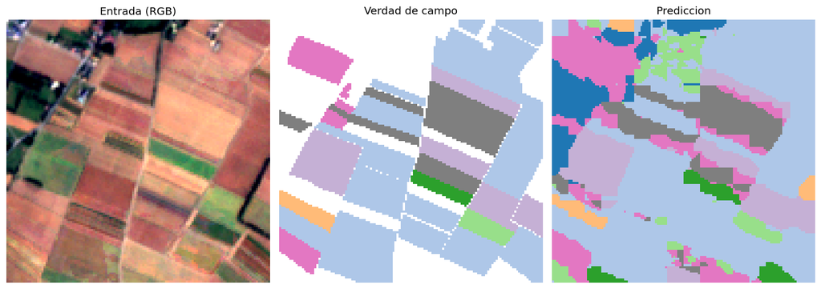

**Patch ejemplo 2: entrada | verdad de campo | prediccion**

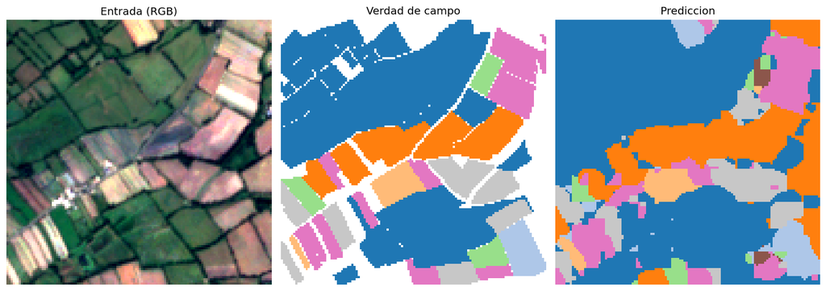

**Patch ejemplo 3: entrada | verdad de campo | prediccion**

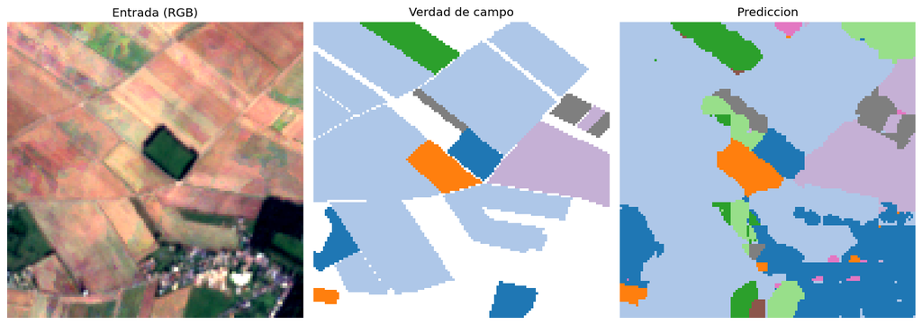

**Matriz de confusion (recall por clase): la diagonal es el acierto.**

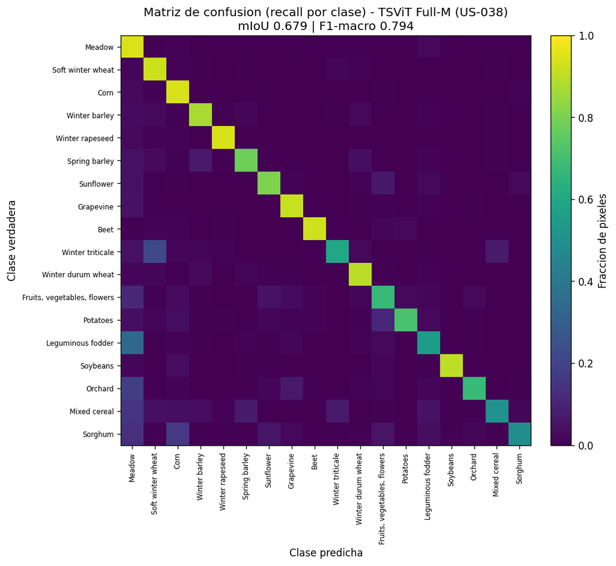

IoU/F1 por clase (orden de mayor a menor IoU):

shape: (10, 4)

| class_id i64 | name str | iou f64 | f1 f64 |
| --- | --- | --- | --- |
| 5 | "Winter rapeseed" | 0.892936 | 0.94344 |
| 9 | "Beet" | 0.889036 | 0.941259 |
| 3 | "Corn" | 0.881041 | 0.936759 |
| 2 | "Soft winter wheat" | 0.868196 | 0.929448 |
| 1 | "Meadow" | 0.86173 | 0.92573 |
| 15 | "Soybeans" | 0.85013 | 0.918995 |
| 8 | "Grapevine" | 0.835749 | 0.910526 |
| 4 | "Winter barley" | 0.787787 | 0.881298 |
| 11 | "Winter durum wheat" | 0.717956 | 0.835826 |
| 7 | "Sunflower" | 0.680486 | 0.809868 |

TSViT-pheno Full-M (US-039) (mIoU 0.675 | F1-macro 0.791 | pixel-acc 0.888)

**Patch ejemplo 1: entrada | verdad de campo | prediccion**

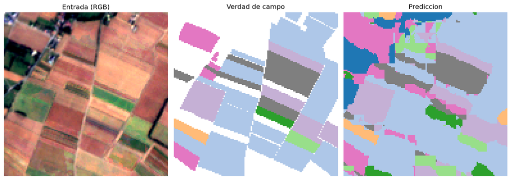

**Patch ejemplo 2: entrada | verdad de campo | prediccion**

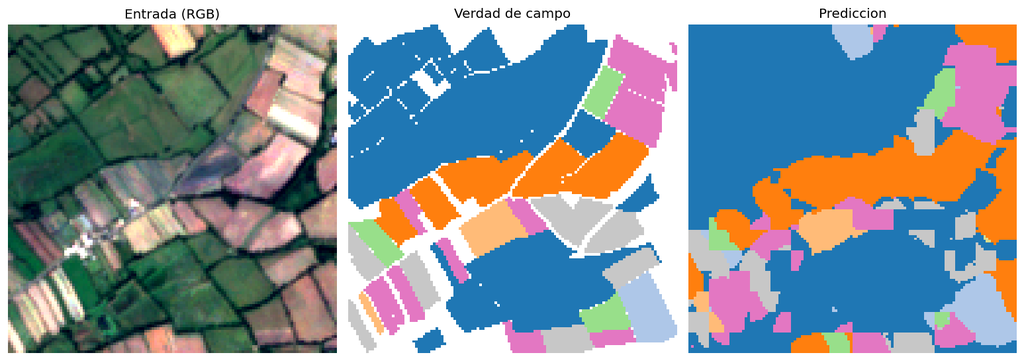

**Patch ejemplo 3: entrada | verdad de campo | prediccion**

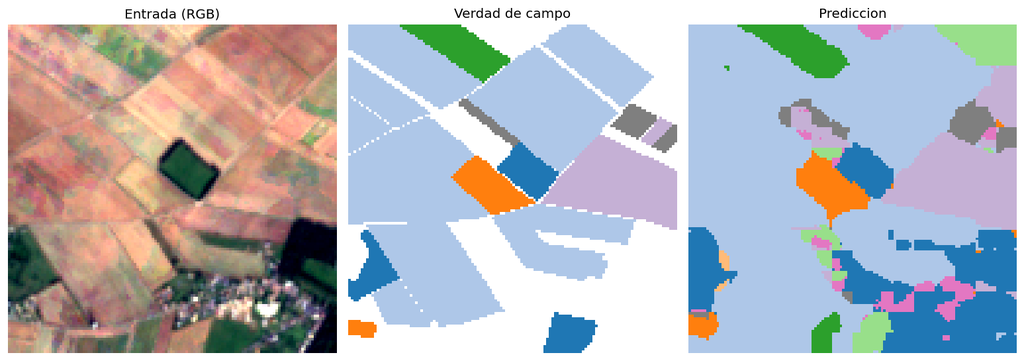

**Matriz de confusion (recall por clase): la diagonal es el acierto.**

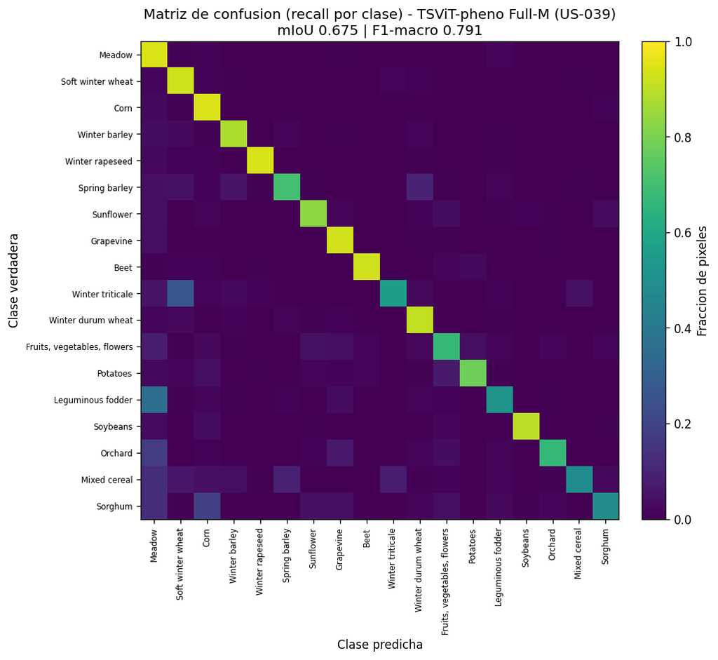

IoU/F1 por clase (orden de mayor a menor IoU):

shape: (10, 4)

| class_id i64 | name str | iou f64 | f1 f64 |
| --- | --- | --- | --- |
| 5 | "Winter rapeseed" | 0.89238 | 0.94313 |
| 3 | "Corn" | 0.879932 | 0.936131 |
| 9 | "Beet" | 0.877255 | 0.934615 |
| 1 | "Meadow" | 0.864597 | 0.927382 |
| 2 | "Soft winter wheat" | 0.863881 | 0.92697 |
| 15 | "Soybeans" | 0.842609 | 0.914582 |
| 8 | "Grapevine" | 0.821005 | 0.901705 |
| 4 | "Winter barley" | 0.797179 | 0.887145 |
| 7 | "Sunflower" | 0.728364 | 0.842836 |
| 11 | "Winter durum wheat" | 0.687534 | 0.814839 |

U-TAE (temporal) (mIoU 0.132 | F1-macro 0.197 | pixel-acc 0.401)

**Patch ejemplo 1: entrada | verdad de campo | prediccion**

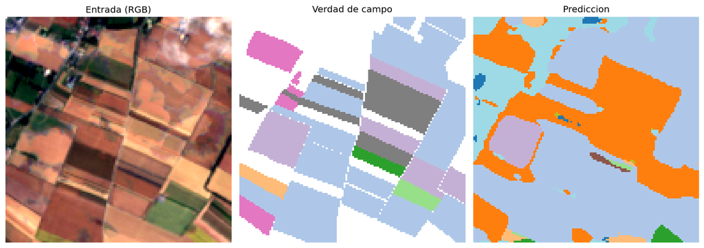

**Patch ejemplo 2: entrada | verdad de campo | prediccion**

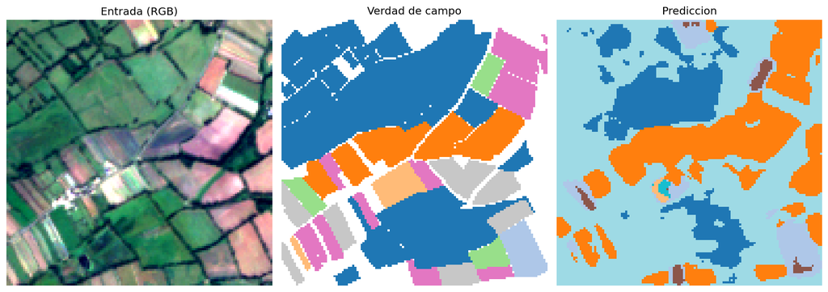

**Patch ejemplo 3: entrada | verdad de campo | prediccion**

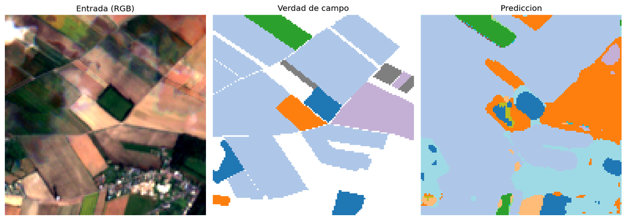

**Matriz de confusion (recall por clase): la diagonal es el acierto.**

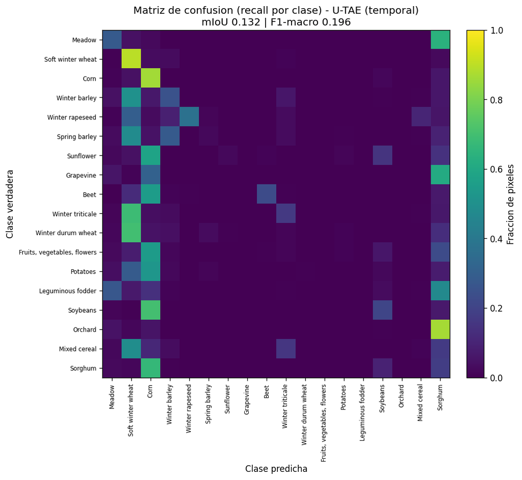

IoU/F1 por clase (orden de mayor a menor IoU):

shape: (10, 4)

| class_id i64 | name str | iou f64 | f1 f64 |
| --- | --- | --- | --- |
| 2 | "Soft winter wheat" | 0.52101 | 0.685084 |
| 3 | "Corn" | 0.518292 | 0.68273 |
| 5 | "Winter rapeseed" | 0.370725 | 0.540918 |
| 1 | "Meadow" | 0.269397 | 0.424449 |
| 9 | "Beet" | 0.221053 | 0.36207 |
| 4 | "Winter barley" | 0.185367 | 0.312758 |
| 15 | "Soybeans" | 0.131908 | 0.233072 |
| 10 | "Winter triticale" | 0.094951 | 0.173434 |
| 7 | "Sunflower" | 0.022804 | 0.04459 |
| 6 | "Spring barley" | 0.017922 | 0.035214 |

DeepLabv3+ (mIoU 0.254 | F1-macro 0.362 | pixel-acc 0.653)

**Patch ejemplo 1: entrada | verdad de campo | prediccion**

[12 more figures not shown]

IoU/F1 por clase (orden de mayor a menor IoU):

shape: (10, 4)

| class_id i64 | name str | iou f64 | f1 f64 |
| --- | --- | --- | --- |
| 2 | "Soft winter wheat" | 0.425764 | 0.597244 |
| 3 | "Corn" | 0.268263 | 0.423039 |
| 5 | "Winter rapeseed" | 0.230475 | 0.374612 |
| 1 | "Meadow" | 0.229114 | 0.372811 |
| 9 | "Beet" | 0.198553 | 0.331321 |
| 16 | "Orchard" | 0.06777 | 0.126938 |
| 8 | "Grapevine" | 0.048156 | 0.091886 |
| 12 | "Fruits, vegetables, flowers" | 0.040915 | 0.078614 |
| 4 | "Winter barley" | 0.038041 | 0.073294 |
| 15 | "Soybeans" | 0.020734 | 0.040625 |

```python
ORDER = ['tsvit', 'tsvit-pheno-fullm', 'utae', 'deeplabv3plus', 'segformer', 'unet']
for kind in ORDER:
    v = MANIFEST.get('segmenters', {}).get(kind)
    if not v or 'error' in (v or {}):
        display(Markdown(f'### {kind}: no disponible'))
        continue
    display(Markdown(f"### {v['label']}  "
        f"(mIoU {v['miou']:.3f} | F1-macro {v['f1_macro']:.3f} | "
        f"pixel-acc {v['pixel_acc']:.3f})"))
    for i, trip in enumerate(v.get('triptychs', [])):
        show_saved_png(FIG_DIR / trip, caption=f'Patch ejemplo {i+1}: entrada | verdad de campo | prediccion')
    show_saved_png(FIG_DIR / v['confusion'], caption='Matriz de confusion (recall por clase): la diagonal es el acierto.')
    pc_path = FIG_DIR / v.get('per_class_csv', '')
    if pc_path.is_file():
        pc = pl.read_csv(pc_path)
        display(Markdown('IoU/F1 por clase (orden de mayor a menor IoU):'))
        display(pc.head(10))
```

## Volcado de probabilidades OOF (insumo de los ensambles)

**US-031: patches del fold-5 con probabilidades OOF volcadas por modelo (todos status=ok).**

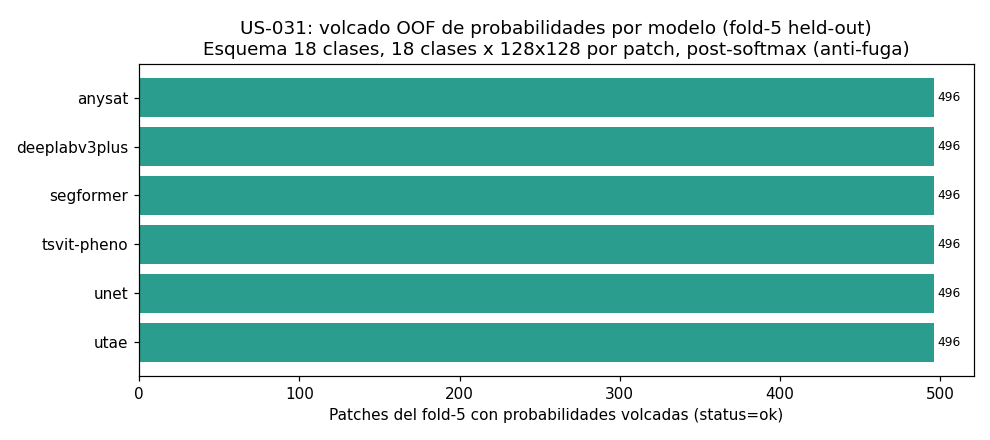

Esquema: **18 clases** x 128x128 por patch, dtype float16, fold 5 held-out. 12 parquet (~1.47 GB) versionados en DVC.

```python
show_saved_png(FIG_DIR / 'us031_oof.png', caption='US-031: patches del fold-5 con probabilidades OOF volcadas por modelo (todos status=ok).')
u031 = REPO / 'ml/eval/oof/manifest.json'
if u031.is_file():
    import json as _json
    mm = _json.loads(u031.read_text(encoding='utf-8'))
    display(Markdown(f"Esquema: **{mm.get('num_classes',18)} clases** x {mm.get('size',128)}x{mm.get('size',128)} por patch, dtype {mm.get('dtype','float16')}, fold {mm.get('fold',5)} held-out. "
        '12 parquet (~1.47 GB) versionados en DVC.'))
```

## Lectura de los resultados

### Lo que sigue

Estas probabilidades por píxel son la materia prima de los ensambles de la libreta 06c.